# vim: Grammar of Text Editing

| Exit |  |
| --- | --- |
| `:w` | Save |
| `:wq` */* `:x` | Save and close file |
| `:q` | Close file |
| `:q!` | Close file, abandon changes |
| `Esc` | Exit insert mode |

| Visual |  |
| --- | --- |
| `v` | Enter visual mode |
| `V` | Enter visual line mode |
| `<C+v>` | Enter visual block mode |
| In Visual Mode |  |
| `d` */* `x` | Delete selection |
| `s` | Replace selection |
| `y` | Yank selection *(Copy)* |

See Operators for other things you can do.

| Macros |  |
| --- | --- |
| `qa` | record macro a |
| `q` | stop recording macro |
| `@a` | run macro a |
| `@@` | rerun last run macro |

| Search/Replace |  |
| --- | --- |
| `/`pattern | search for pattern |
| `?`pattern | search backward for pattern |
| `n` | repeat search in same direction |
| `N` | repeat search in opposite direction |
| `:%s/old/new/g` | replace all old with new throughout file |
| `:%s/old/new/gc` | with confirmations |
| Search Range |  |
| `.` | the current line |
| `$` | the last line in the file |
| `%` | the whole file. The same as `1,$` |

| Navigate |  |
| --- | --- |
| Character |  |
| `h` `j` `k` `l` | Arrow keys |
| Word |  |
| `b` */* `w` | Previous/next word |
| `ge` */* `e` | Previous/next end of word |
| Line |  |
| `0` *(zero)* | Start of line |
| `^` | Start of line *(after whitespace)* |
| `$` | End of line |
| Character |  |
| `fc` | Go forward to character `c` |
| `Fc` | Go backward to character `c` |
| `;` | repeat previous f, F movement |
| `,` | repeat previous f, F movement backwards |
| Document |  |
| `gg` | First line |
| `G` | Last line |
| `:n` | Go to line `n` |
| `nG` | Go to line `n` |
| Screen |  |
| `zz` | Center this line |
| `zt` | Top this line |
| `zb` | Bottom this line |
| `H` | Move to top of screen |
| `M` | Move to middle of screen |
| `L` | Move to bottom of screen |
| `<C+u>` */* `<C+d>` | Half-page up/down |
| `<C+b>` */* `<C+f>` | Page up/down |
| Mark |  |
| `ma` | Mark this cursor position as `a` |
| `a | Jump to the marked position `a` |
| Match |  |
| `*` | Next whole word under cursor |
| `#` | Previous whole word under cursor |
| `%` | Nearest/matching `{[()]}` |
| `[(` `[{` `[<` | Previous `(` or `{` or `<` |
| `])` | Next |

| Edit |  |
| --- | --- |
| Insert |  |
| `a` | Append |
| `A` | Append from end of line |
| `i` | Insert |
| `o` | Open a new line below and insert |
| `O` | Open a new line above and insert |
| Deleta |  |
| `x` | Delete character |
| `dw` | Delete word |
| `dd` | Delete line *(Cut)* |
| Substitute |  |
| `s` | Substitute char and insert |
| `S` | Substitute line and insert |
| Change |  |
| `c` | change |
| `C` | Delete until end of line and insert |
| `r` | Replace one character |
| `R` | Enter Replace mode |
| Yank |  |
| `yy` | yank (copy) a line |
| `2yy` | yank (copy) 2 lines |
| `ye` | yank (copy) the characters of the word from the cursor position |
| `y$` | yank (copy) to end of line |
| Paste |  |
| `p` | Paste |
| `P` | Paste before |
| Join |  |
| `J` | Join the next line to the current |
| Capitalize |  |
| `~` | Toggle case (Case => cASE) |
| `gU` | Uppercase |
| `gu` | Lowercase |
| `gUU` | Uppercase current line (also `gUgU`) |
| `guu` | Lowercase current line (also `gugu`) |
| Undo/Redo |  |
| `u` | Undo changes |
| `<C+r>` | Redo changes |

## Commanding your text editor

### (Numeric Qualifier +) Verb + Preposition + Noun

Operators (Verb) let you operate in a range of text (Noun) defined by *motion* (Preposition).

| Verb | Noun |
| --- | --- |
| `d` | `w` |
| Operator | Motion |

| Operator |  |
| --- | --- |
| `d` | Delete |
| `y` | Yank *(copy)* |
| `c` | Change *(delete then insert)* |

| Verb+Noun | Sentence |
| --- | --- |
| `d`*d* | *(repeat the letter)* Delete current line |
| `d`*w* | Delete to next word |
| `d`*b* | Delete to beginning of word |
| *2*`dd` | Delete 2 lines |
| `d`*ip* | Delete a text object *(inside paragraph)* |
| *(in visual mode)* `d` | Delete selection |

## Operand: Text objects

Text objects let you operate (with an *operator*) in or around text blocks (*objects*).

### Grammar

| Operator | [i]nside or [t]ill | Text object |
| --- | --- | --- |
| `v` | `i` `a` `t` | `p` |

| Oprand |  |
| --- | --- |
| `p` | Paragraph |
| `w` | Word |
| `s` | Sentence |
| `[` `(` `{` `<` | A [], (), or {} block |
| `'` `"` ` | A quoted string |
| `b` | A block [( |
| `B` | A block in [{ |
| `t` | A XML tag block |

### Verb + Preposition + Noun

| Sentence | Action |
| --- | --- |
| `vip` | Select paragraph |
| `vipipipip` | Select more |
| `yip` | Yank inner paragraph |
| `yap` | Yank paragraph (including newline) |
| `dip` | Delete inner paragraph |
| `cip` | Change inner paragraph |

See Operators for other things you can do.

### RStudio configuration for `vim` binding

`Tools` – `Global Options..` – `Code` – `Editing`

[figure not shown]

`vim` is THE text editor you, as an R scripter, have no excuse not to know!

- The 80/20 rule applies; that is, when you’re coding, you spend 8\0% of your typing in **commanding** editor, and 20% in **entering** texts.
- In **commanding** mode, every single key in your keyboard will be tapped on as “hot-key” in `vim`
- The secret of mastering `vim` is in understanding the simple grammar of your command: `verb`, `noun`, `preposition`, and `qualifier`
  - It is the grammar that produces zillon sentences!
  - Enjoy the editing magic with hundreds of hot-keys which bring about ten folds of coding productivity!
- `vim` will also cooperate peacefully with the `RStudio` hot-keys such as `<C>+<A>+i`, `<C>+<S>+M`, etc.

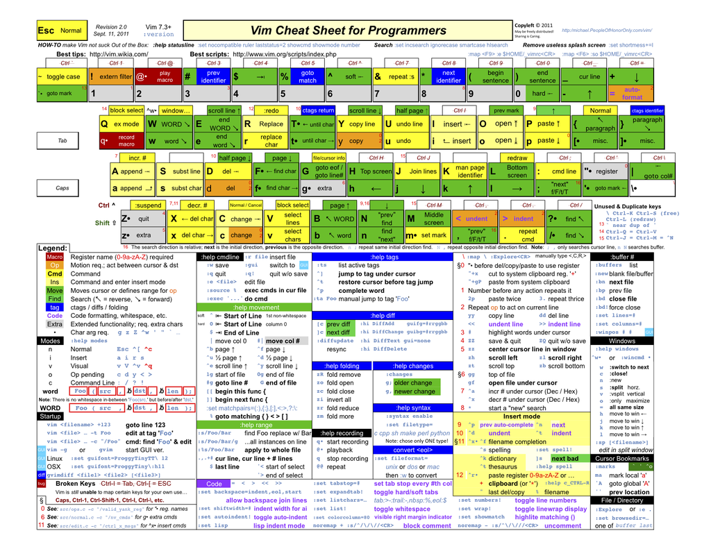

[video not shown]

Also see

- [Vim cheatsheet](https://vim.rtorr.com/) *(vim.rotrr.com)*
- [Vim documentation](http://vimdoc.sourceforge.net/htmldoc/) *(vimdoc.sourceforge.net)*
- [Interactive Vim tutorial](http://openvim.com/) *(openvim.com)*